# 第１回課題

> オブジェクト指向プログラミングおよび演習1 第1回

## 1.複数行画面にテキストを出力するプログラム

実行すると、以下の出力内容に従い、一言一句間違いないように出力してください。

```bash
Hello, World!!
Hello, Java!!
Hello, Friends!!
```

以下、指定する条件にしたがってください。

| ファイル名 | クラス名 |
| --- | --- |
| `HelloKadai.java` | HelloKadai |

## 2.画面から入力されたテキストをそのまま出力するプログラム

サンプルソースに少し手を加えるだけですが、これも動作確認を行った上で提出しましょう。  
以下の実行結果と同様の出力となるようにしてください。

#### 入力待受前のメッセージ表示

```bash
こんにちは、メッセージをどうぞ
```

#### (ユーザー操作)テキストを入力

入力内容はサンプルです。いろいろ変えて実行確認しましょう。

```bash
ほげほげ
```

#### 入力後の応答

ユーザーからの入力をメッセージとして受け取り、以下のメッセージで確認します。

```bash
メッセージを受信しました
----
ほげほげ
----
```

以下、指定する条件にしたがってください。

| ファイル名 | クラス名 |
| --- | --- |
| `MessageInput.java` | MessageInput |

## 3.画面から入力された数値に対して100をかけた積を出力するプログラム

こちらもサンプルソースに少し手を加えるだけですが、これも動作確認を行った上で提出しましょう。  
以下の実行結果と同様の出力となるようにしてください。

#### 入力待受前のメッセージ表示

```bash
整数値を入力してください
```

#### (ユーザー操作)テキストを入力

入力内容はサンプルです。いろいろ変えて実行確認しましょう。

```bash
123
```

#### 入力後の応答

```bash
計算結果：12300
```

**整数値ではない文字列が入力された場合は、例外が送出されてエラーとなりプログラム終了でOKです。**

以下、指定する条件にしたがってください。

| ファイル名 | クラス名 |
| --- | --- |
| `Multiplication100.java` | Multiplication100 |

# 提出について

moodleにて提出先を作成します。

3つの課題として作成したソースコードを提出してください。 (javaファイルのみです。.classとついたファイルは提出不要です。)

また、提出時のファイルの圧縮は不要です。 こちらは3つのファイルが1つの提出先に提出されることを想定しています。 ファイル名が指定と異なる場合は減点の対象となります。よく確認して提出してください。

# チャレンジ課題

この課題は、通常の課題とは別枠の課題です。 さらに上を目指したい生徒はぜひチャレンジしてください。

資料「プログラムを書いてみる」のGUIアプリケーションのサンプルを参考に、以下の条件で改変したプログラムを作成してください。

GUIアプリの起動時の画面は以下の通りです。

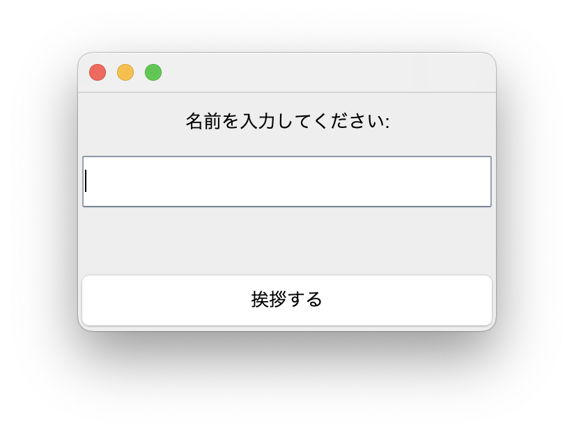

`たろう`と入力して、ボタンを押下すると以下の画面になります。

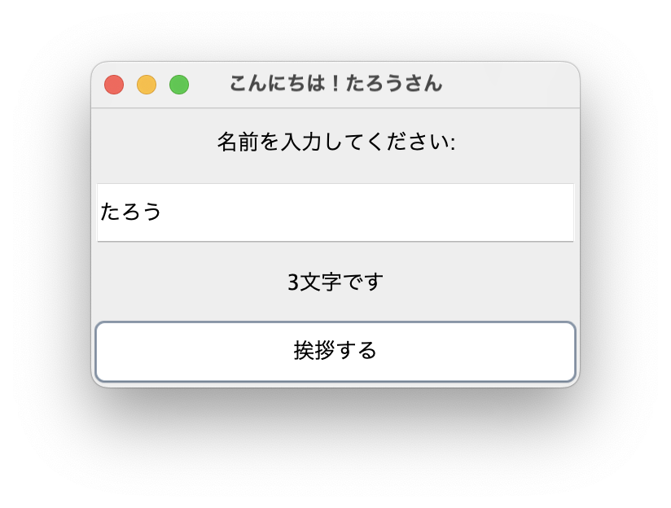

詳細な機能を以下にまとめます。

1. 起動時
   - タイトルは空文字とする
   - それ以外の画面のコンポーネントはサンプルと同じとする
2. ボタン押下時
   - アプリケーションのタイトルを「こんにちは！○○さん」とする ※○○は入力された文字列を表示
   - サンプルで挨拶を表示していたラベルには、入力された文字列の長さを「n文字です」の形式で表示する

ファイル名、クラス名は以下の条件にしたがってください。

| ファイル名 | クラス名 |
| --- | --- |
| `GreetAndShowLength.java` | GreetAndShowLength |

## チャレンジ課題の提出について

moodleに別の提出先として作成されています。通常の課題の方に出した場合は評価されません。

こちらの課題が提出できなくても、課題全体は未提出とはなりません。

提出するファイルは、`GreetAndShowLength.java`に加えて、以下のレポート形式でテキストファイルを提出してください。

- ファイル名「`K00000_01_add.md`」※K00000は自分の学籍番号とする
- 内容は以下のテンプレートに従う
- 参考文献については、調べたURL等を事細かに記録しておくこと
  - LLMを使った場合、リンク共有が可能であればリンク共有を行う
  - リンク共有が行えない場合は、どのように聞いたかのプロンプトも同時に記載すること

### テンプレート

```markdown
第1回 チャレンジ課題レポート
----

Author: K00000 愛工太郎

## 参考文献

- 参考にしたサイトのURL
- 参考にした書籍名とページ番号
- などを箇条書きする
```